# Yes or No? Classifying Term Deposit Subscriptions using Random Forest

Aiden

# Variable Description

-age

-job - type of job (categorical:‘admin.’,‘blue-collar’,‘entrepreneur’,‘housemaid’,‘management’,‘retired’,‘self-employed’,‘services’,‘student’,‘technician’,‘unemployed’,‘unknown’)  
-marital - marital status (categorical: ‘divorced’,‘married’,‘single’,‘unknown’; note: ‘divorced’ means divorced or widowed)  
-education - (categorical: ‘basic.4y’,‘basic.6y’,‘basic.9y’,‘high.school’,‘illiterate’,‘professional.course’,‘university.degree’,‘unknown’) -default - has credit in default?  
-balance - average yearly balance  
-housing - has housing loan?  
-loan - has personal loan?  
-contact - contact communication type (categorical: ‘cellular’,‘telephone’) -day_of_week - last contact day of the week -month - last contact month of year (categorical: ‘jan’, ‘feb’, ‘mar’, …, ‘nov’, ‘dec’)  
-duration - last contact duration, in seconds (numeric) -day - date of the month -campaign - number of contacts performed during this campaign and for this client (numeric, includes last contact)  
-pdays - number of days that passed by after the client was last contacted from a previous campaign (numeric; -1 means client was not previously contacted) -previous - number of contacts performed before this campaign and for this client  
-poutcome - outcome of the previous marketing campaign (categorical: ‘failure’,‘nonexistent’,‘success’) -y - has the client subscribed a term deposit?

# Libraries

```r
library(readr)
library(dplyr)
library(rpart)
library(rpart.plot)
library(randomForest)
library(party)
library(caret)
library(caTools)
library(pROC)
```

# Reading in the data

```r
bank.data = read_delim("bank.csv", delim = ";",
    escape_double = FALSE, trim_ws = TRUE)
```

Inspecting the class of each variable

```r
sapply(bank.data, class)
```

```
##         age         job     marital   education     default     balance
##   "numeric" "character" "character" "character" "character"   "numeric"
##     housing        loan     contact         day       month    duration
## "character" "character" "character"   "numeric" "character"   "numeric"
##    campaign       pdays    previous    poutcome           y
##   "numeric"   "numeric"   "numeric" "character" "character"
```

Adjusting all binary variables into factors

```r
bank.data$default = as.factor(bank.data$default)
bank.data$housing = as.factor(bank.data$housing)
bank.data$loan = as.factor(bank.data$loan)
bank.data$y = as.factor(bank.data$y)
```

Checking for any NA values in the dataset

```r
any(is.na(bank.data)) # Finding if there are any NA values in our dataset
```

```
## [1] FALSE
```

Upon inspection, there are unknown inputs across different columns in the dataset.

Some inputs are unknown. Therefore I will remove them since we have a relatively large number of observations

```r
adj.bank.data = subset(bank.data, contact!= "unknown")
adj.bank.data = subset(adj.bank.data, job!= "unknown")
adj.bank.data = subset(adj.bank.data, marital!= "unknown")
adj.bank.data = subset(adj.bank.data, education!= "unknown")
adj.bank.data = subset(adj.bank.data, loan!= "unknown")
adj.bank.data = subset(adj.bank.data, month!= "unknown")
```

A large number of the outcomes of the previous marketing campaign are unknown which isn’t very useful in comparative analysis across levels.

```r
print(sum(bank.data$poutcome == "unknown")) # Finding the number of outcomes of previous marketing campaign which are unknown
```

```
## [1] 3705
```

Remove unnecessary columns

```r
adj.bank.data$poutcome = NULL
adj.bank.data$day = NULL # Removing date of the month
adj.bank.data$month = NULL
```

A large number of previous number of days that passed by after the client was last contacted from a previous campaign are -1, indicating most of the clients have not been contacted before. Therefore, I will remove pdays.

```r
print(sum(bank.data$pdays == -1))
```

```
## [1] 3705
```

```r
# Remove pdays column
adj.bank.data$pdays = NULL
```

Is the dataset imbalanced?

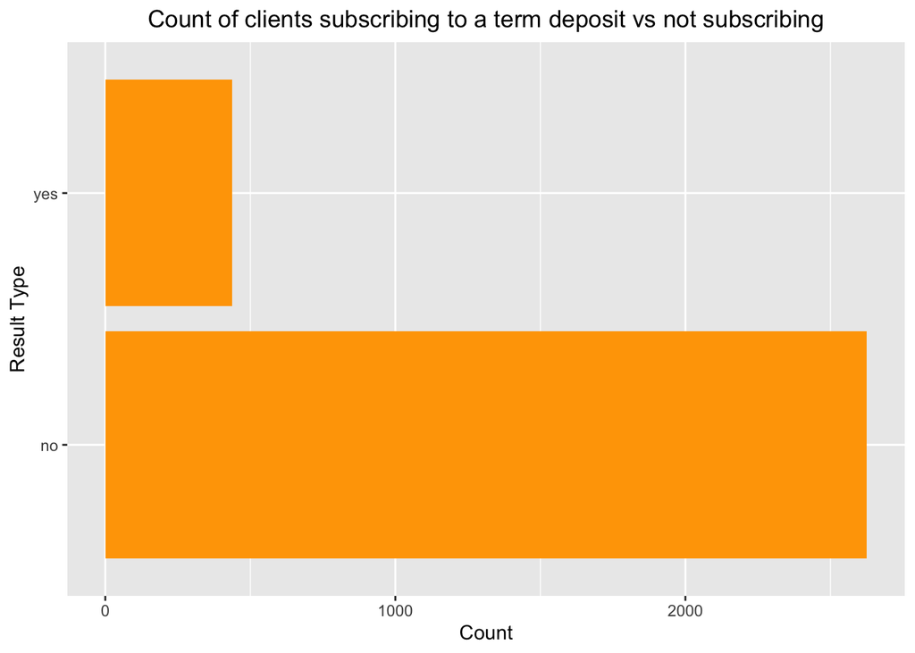

```r
ggplot(data = adj.bank.data, mapping = aes(y=y))+
  geom_bar(fill="orange")+
  labs(x="Count", y="Result Type", title="Count of clients subscribing to a term deposit vs not subscribing")+
    theme(plot.title = element_text(hjust = 0.5))
```

Massively imbalanced dataset where there more negative case is the majority class, and the positive case is the minority class.

Upsampling the minority class (yes to subscribing) to create a balanced dataset

```r
balanced_data = upSample(x = adj.bank.data[, -which(names(adj.bank.data) == "y")],
                          y = adj.bank.data$y)
colnames(balanced_data)[colnames(balanced_data) == "Class"] = "y"
```

Double checking the dataset is balanced

```r
table(balanced_data$y)
```

```
##
##   no  yes
## 2626 2626
```

Splitting the data into training and test sets

```r
# Splitting data in train and test data
split = sample.split(balanced_data$y, SplitRatio = 0.7) # 70-30 split for training vs test set

train.data = subset(balanced_data, split == "TRUE") # Subsetting dataset into training set
test.data = subset(balanced_data, split == "FALSE") # Subsetting dataset into test set
test.y = test.data$y
test.data$y = NULL
```

Double checking the response is now balanced between positive and negative class.

```r
table(train.data$y)
```

```
##
##   no  yes
## 1838 1838
```

Fitting a decision tree with all possible variables

```r
tree_model = rpart(y ~ ., data = train.data, method = "class")
```

```r
print(tree_model) # Inspecting the model
```

```
## n= 3676
##
## node), split, n, loss, yval, (yprob)
##       * denotes terminal node
##
##  1) root 3676 1838 no (0.5000000 0.5000000)
##    2) duration< 211.5 1437  277 no (0.8072373 0.1927627) *
##    3) duration>=211.5 2239  678 yes (0.3028138 0.6971862)
##      6) duration< 638.5 1597  599 yes (0.3750783 0.6249217)
##       12) previous< 0.5 1006  463 yes (0.4602386 0.5397614)
##         24) job=blue-collar,services 208   65 no (0.6875000 0.3125000)
##           48) duration< 474.5 143   23 no (0.8391608 0.1608392) *
##           49) duration>=474.5 65   23 yes (0.3538462 0.6461538) *
##         25) job=admin.,entrepreneur,housemaid,management,retired,self-employed,student,technician,unemployed 798  320 yes (0.4010025 0.5989975) *
##       13) previous>=0.5 591  136 yes (0.2301184 0.7698816) *
##      7) duration>=638.5 642   79 yes (0.1230530 0.8769470) *
```

[figure not shown]

```r
plot(tree_model) # Visualising the tree
```

Creating predictions and confusion matrix based on the decision tree

```r
predictions = predict(tree_model, newdata = test.data, type = "class") # Predictions

conf_matrix = confusionMatrix(predictions, test.y) # Building Confusion matrix
print(conf_matrix$byClass)
```

```
##          Sensitivity          Specificity       Pos Pred Value
##            0.7055838            0.8172589            0.7942857
##       Neg Pred Value            Precision               Recall
##            0.7351598            0.7942857            0.7055838
##                   F1           Prevalence       Detection Rate
##            0.7473118            0.5000000            0.3527919
## Detection Prevalence    Balanced Accuracy
##            0.4441624            0.7614213
```

Not amazing predictive statistics from the decision tree, but we can do better.

How about a Random Forest method? Random Forest delivers highly accurate predictions even with large datasets, effectively handles missing data without sacrificing accuracy, eliminates the need for normalization or standardisation, and reduces the risk of overfitting by combining multiple decision trees.

```r
rf.model = randomForest(y~., data = train.data, importance = TRUE)
```

Inspecting the random forest model

```r
print(rf.model)
```

```
##
## Call:
##  randomForest(formula = y ~ ., data = train.data, importance = TRUE)
##                Type of random forest: classification
##                      Number of trees: 500
## No. of variables tried at each split: 3
##
##         OOB estimate of  error rate: 5.58%
## Confusion matrix:
##       no  yes class.error
## no  1642  196 0.106637650
## yes    9 1829 0.004896627
```

Looking at the error rates

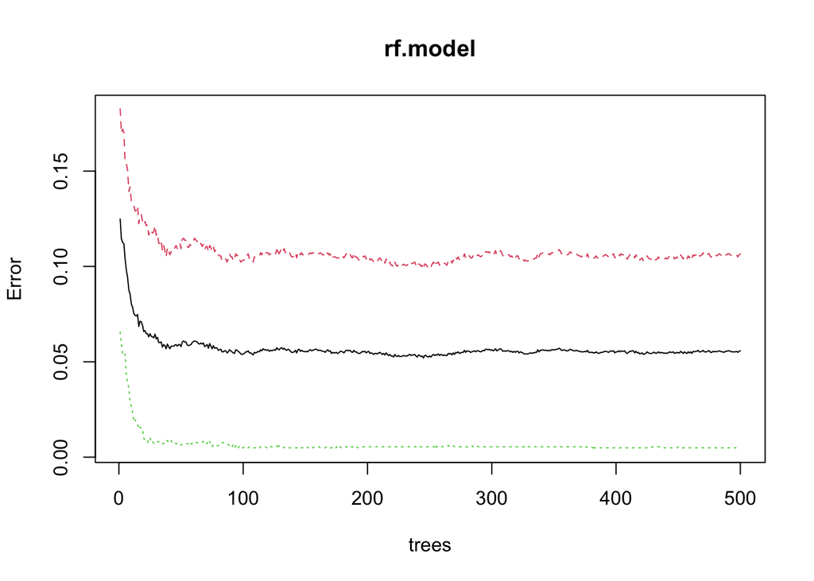

```r
plot(rf.model)
```

Checking the important features

```r
# Feature importance
importance(rf.model)
```

```
##                    no       yes MeanDecreaseAccuracy MeanDecreaseGini
## age         7.8203810 106.93976            101.93160       226.310099
## job         2.5358763  69.54973             67.86718       105.940117
## marital     0.4824615  54.21990             52.77171        53.421268
## education   7.0691136  58.88730             58.32590        54.198252
## default    -1.5655663  20.48526             19.84366         4.423608
## balance     7.5423798  88.73978             84.77478       264.716881
## housing    14.5055201  56.74702             57.74061        44.449054
## loan        4.2723634  47.25619             46.68790        32.281472
## contact     0.9793592  42.78319             41.34549        19.633871
## duration  109.5200016 190.65215            193.20537       717.480023
## campaign    5.0848354  73.43000             70.80699       100.359862
## previous   24.7804442  96.07897             95.84603       115.278277
```

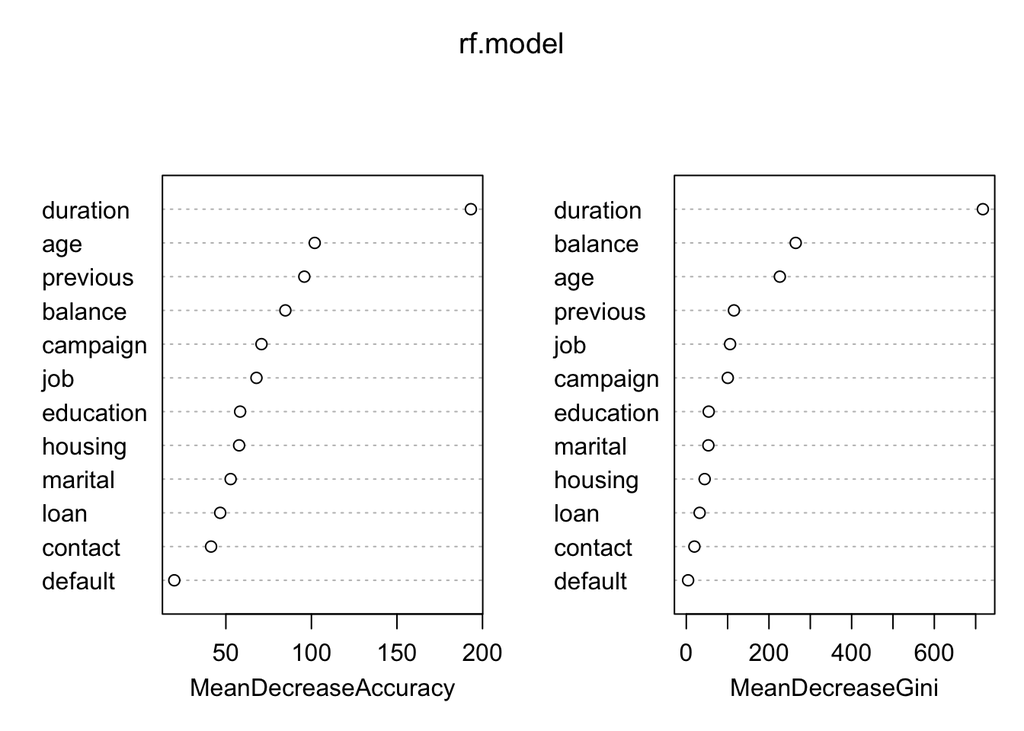

```r
varImpPlot(rf.model)
```

duration is the most critical variable, as excluding it would lead to the largest drop in accuracy, followed by age and balance (average of the two plots). Similarly, duration is the most important variable when it comes to contributing to the homogeneity of the nodes and leaves in the decision trees.

The bottom 3 variables in both plots: default, contact, and loan are the least important when it comes to a drop in accuracy and the Gini.

Therefore, I’ll refit the model and omit default, contact, and loan.

```r
new.train = train.data
# new training data without 'default', 'contact', and 'loan'.
new.train$default = NULL
new.train$contact = NULL
new.train$loan = NULL

new.test = test.data
# new test data without 'default', 'contact', and 'loan'.
new.test$default = NULL
new.test$contact = NULL
new.test$loan = NULL
```

```r
# adjusted Random Forest model without default, contact, and loan
adj.rf.model = randomForest(y~., data = new.train, importance=TRUE)
```

Inspecting the adjusted random forest model

```r
# Evaluate the model
print(adj.rf.model)
```

```
##
## Call:
##  randomForest(formula = y ~ ., data = new.train, importance = TRUE)
##                Type of random forest: classification
##                      Number of trees: 500
## No. of variables tried at each split: 3
##
##         OOB estimate of  error rate: 5.58%
## Confusion matrix:
##       no  yes class.error
## no  1641  197 0.107181719
## yes    8 1830 0.004352557
```

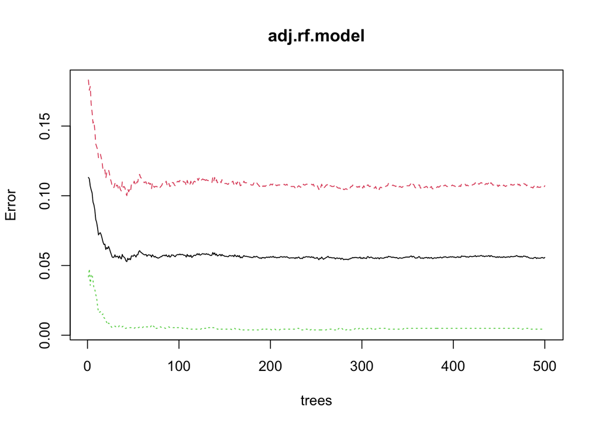

```r
plot(adj.rf.model)
```

Similar story to the original model rf.model.

Let’s inspect the relationship between the most important variables and the probability of a yes to subscribing to the term deposits.

Starting with duration

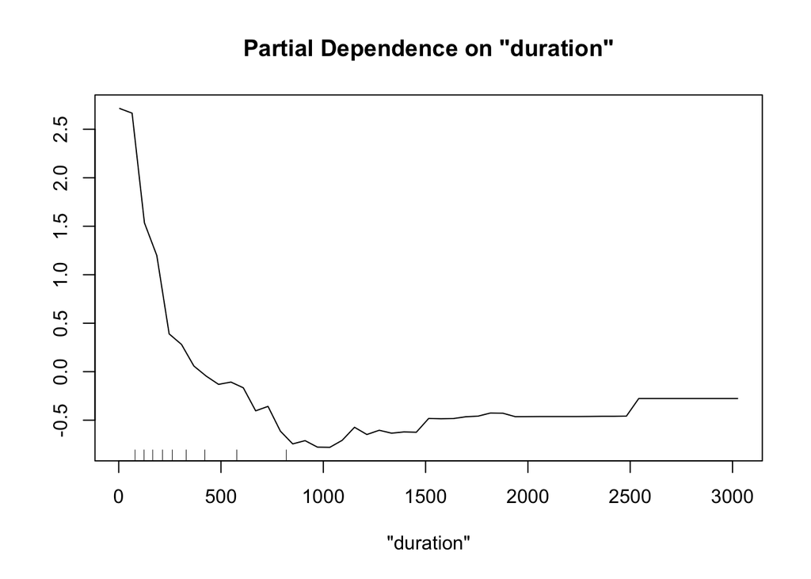

```r
# Inspecting the relationship of the last contact duration
partialPlot(adj.rf.model, new.train, x.var = "duration")
```

How about age?

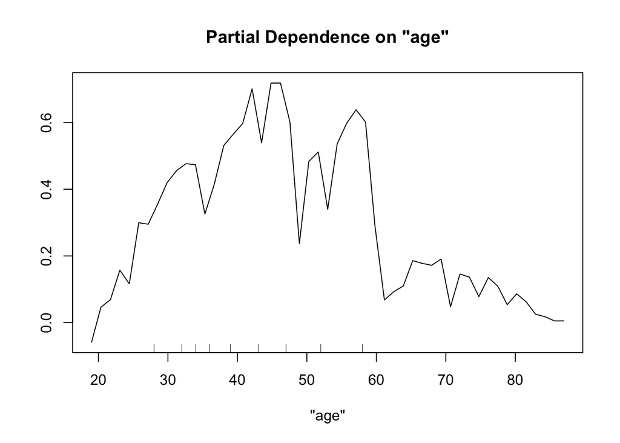

```r
partialPlot(adj.rf.model, new.train, x.var = "age")
```

What about balance - average yearly balance?

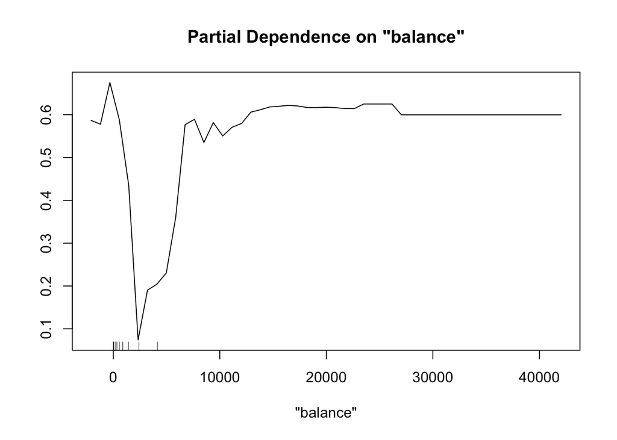

```r
# Inspecting the relationship of the last contact duration
partialPlot(adj.rf.model, new.train, x.var = "balance")
```

Creating predictions and constructing the confusion matrix for the Random Forest model

```r
# Creating predictions based on the fitted model and test data
predictions.rf = predict(adj.rf.model, newdata = new.test, type = "class")

conf_matrix.rf = confusionMatrix(predictions.rf, test.y) # Creating the confusion matrix for the Random Forest model
print(conf_matrix.rf$byClass)
```

```
##          Sensitivity          Specificity       Pos Pred Value
##            0.9149746            0.9974619            0.9972337
##       Neg Pred Value            Precision               Recall
##            0.9214537            0.9972337            0.9149746
##                   F1           Prevalence       Detection Rate
##            0.9543349            0.5000000            0.4574873
## Detection Prevalence    Balanced Accuracy
##            0.4587563            0.9562183
```

Good statistics.

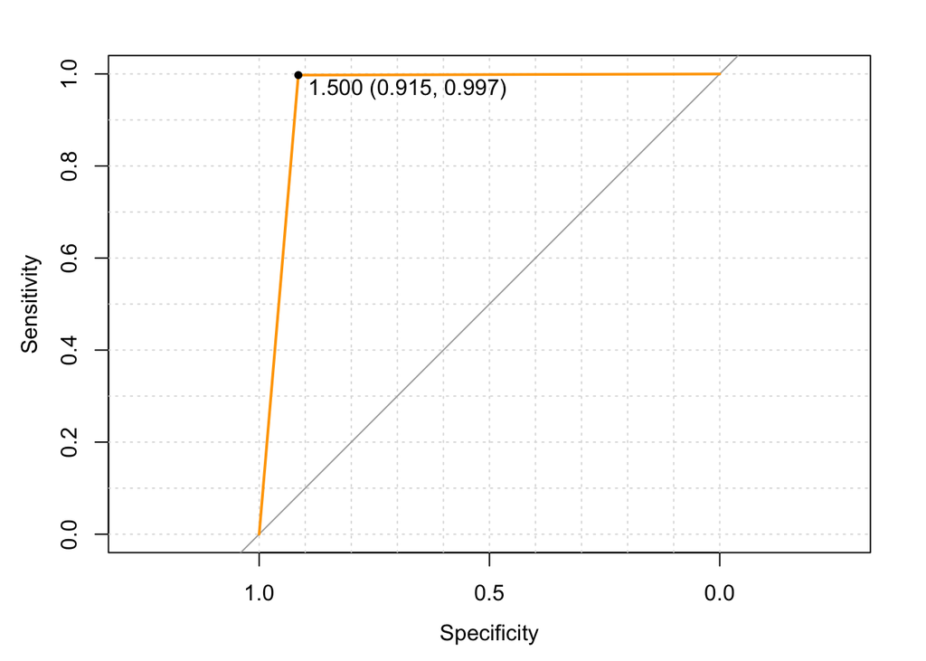

```r
# Estimate of AUC
roc_curve = roc(test.y, as.numeric(predictions.rf)) # ROC curve
plot(roc_curve, grid=TRUE, col="orange",print.thres = "best") #Plot ROC curve alongside the point that maximises both sensitivity and specificity
```

What’s the AUC for the ROC curve?

```r
print(auc(roc_curve))
```

```
## Area under the curve: 0.9562
```

The adjusted Random Forest model (adj.rf.model) is a great predictor of the binary classes. The model is good at distinguishing between a ‘yes’ or a ‘no’ in the response.

What about the error rate of the Random Forest model?

```r
adj.rf.model$err.rate
```

[output not shown]

[output cut: 486 more lines]

As more trees are added to the model, the OOB error decreases until around 0.05.

# Final model

```r
# Final model
print(adj.rf.model)
```

```
##
## Call:
##  randomForest(formula = y ~ ., data = new.train, importance = TRUE)
##                Type of random forest: classification
##                      Number of trees: 500
## No. of variables tried at each split: 3
##
##         OOB estimate of  error rate: 5.58%
## Confusion matrix:
##       no  yes class.error
## no  1641  197 0.107181719
## yes    8 1830 0.004352557
```

# Actionable insight

The most important features of the marketing campaign is duration - last contact duration, in seconds, age, and balance - average yearly balance.

Saving the model into a file for access

```r
saveRDS(adj.rf.model, "bankmarketing_rf.rds")
```